# Project on Heart Diseases

#### 1) How do a person’s age and gender affect their risk of heart disease?

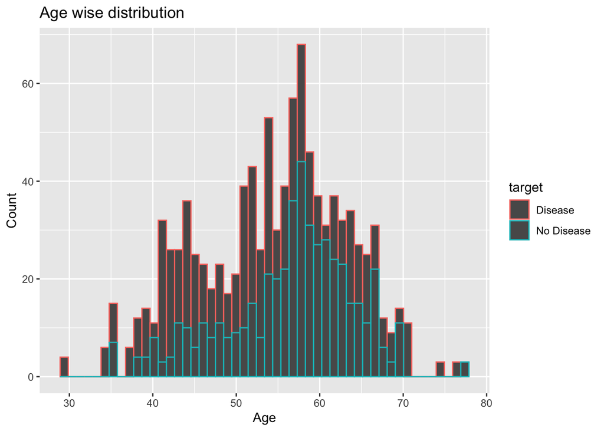

```r
ggplot(df1, mapping=aes(x=age, color = target)) + geom_histogram(bins = 50) +
  labs(x = "Age", y = "Count", title = 'Age wise distribution')
```

```r
df2 <-df
df2$age_group <- cut(df1$age, breaks=seq(25,80, 5))

age_group <- df2 |>
  group_by(age_group) |>
  summarise(target = sum(target))
na.omit(age_group)
```

```
# A tibble: 11 × 2
   age_group target
   <fct>      <int>
 1 (25,30]        4
 2 (30,35]       14
 3 (35,40]       27
 4 (40,45]      111
 5 (45,50]       55
 6 (50,55]      117
 7 (55,60]       87
 8 (60,65]       56
 9 (65,70]       38
10 (70,75]       14
11 (75,80]        3
```

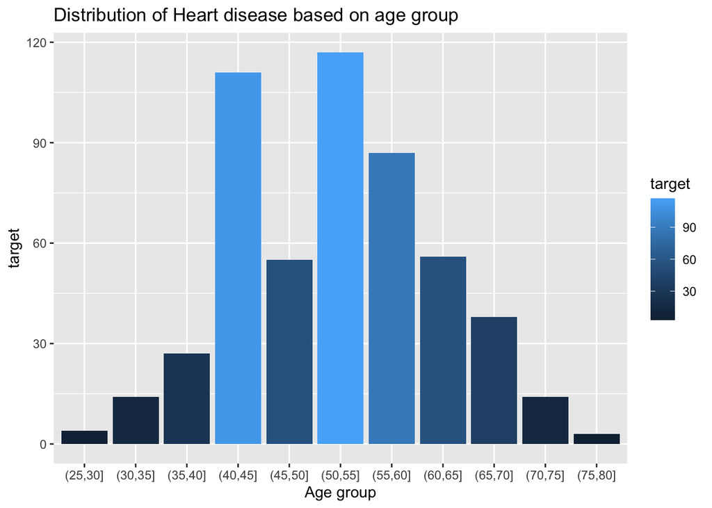

```r
age_plot <- df2 |>
  group_by(age_group) |>
  summarise(target = sum(target)) |>
  ggplot(df, mapping = aes(x= age_group, y= target, fill = target)) + geom_col(position = "dodge") + labs(x = 'Age group', y = "target", title = "Distribution of Heart disease based on age group")

na.omit(age_plot)
```

### From the graph above, the age group 40-45 years and 50-55years are more likely at risk of heart disease.

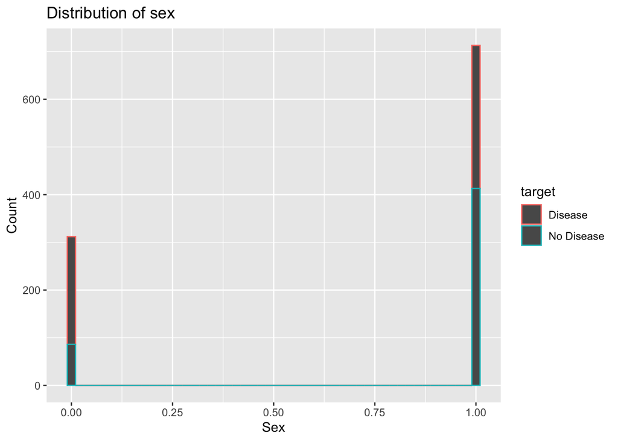

```r
#Distribution of Chest pain type
ggplot(df1, mapping=aes(x = df$sex, color = target)) + geom_histogram(bins =50) +
labs(x="Sex", y="Count", title="Distribution of sex ")
```

```r
round(prop.table(table(df1$sex)),2)
```

```
Female   Male
   0.3    0.7
```

```r
round(prop.table(table(df1$sex, df1$target)),2)
```

```
         Disease No Disease
  Female    0.22       0.08
  Male      0.29       0.40
```

#### 2) What are the other risk factors causing the heart disease?

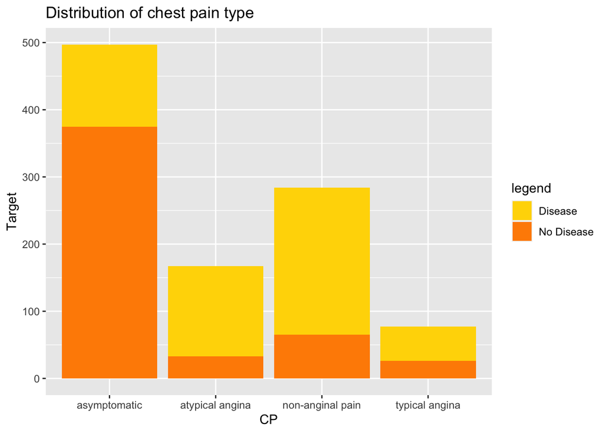

```r
df1 %>%
  ggplot()+
  geom_bar(mapping = aes(x= cp, fill = target)) + labs(x="CP", y="Target", title="Distribution of chest pain type ") +
  scale_fill_manual("legend", values = c("Disease" = "gold", "No Disease" = "dark orange"))
```

#### From the above plot, chest pain seems to appear more with heart disease patients whereas, with no heart disease, patients are comparatively less to feel chest pain.

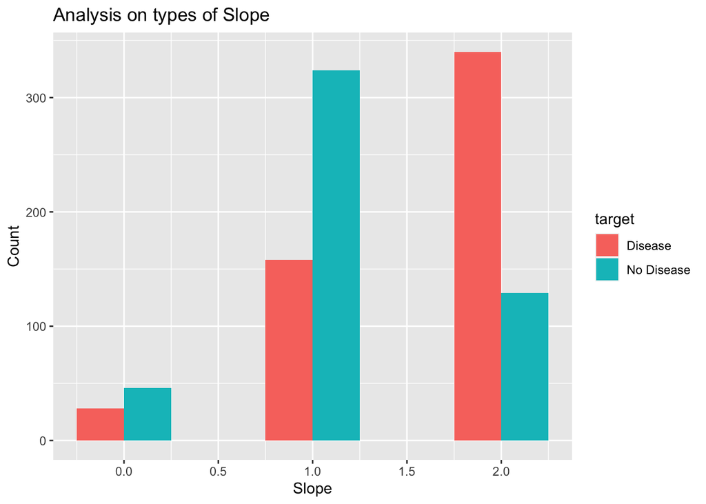

```r
ggplot(df1, aes(x= df$slope, fill=target)) + geom_histogram(position="dodge", bins=5) +
  labs(x="Slope", y="Count", title = "Analysis on types of Slope")
```

#### We can observe that those who exercise on an upslope have a higher risk of developing heart disease than those who exercise on a flat or downward slope. Let’s look at the age range that participates in the upsloping exercise.

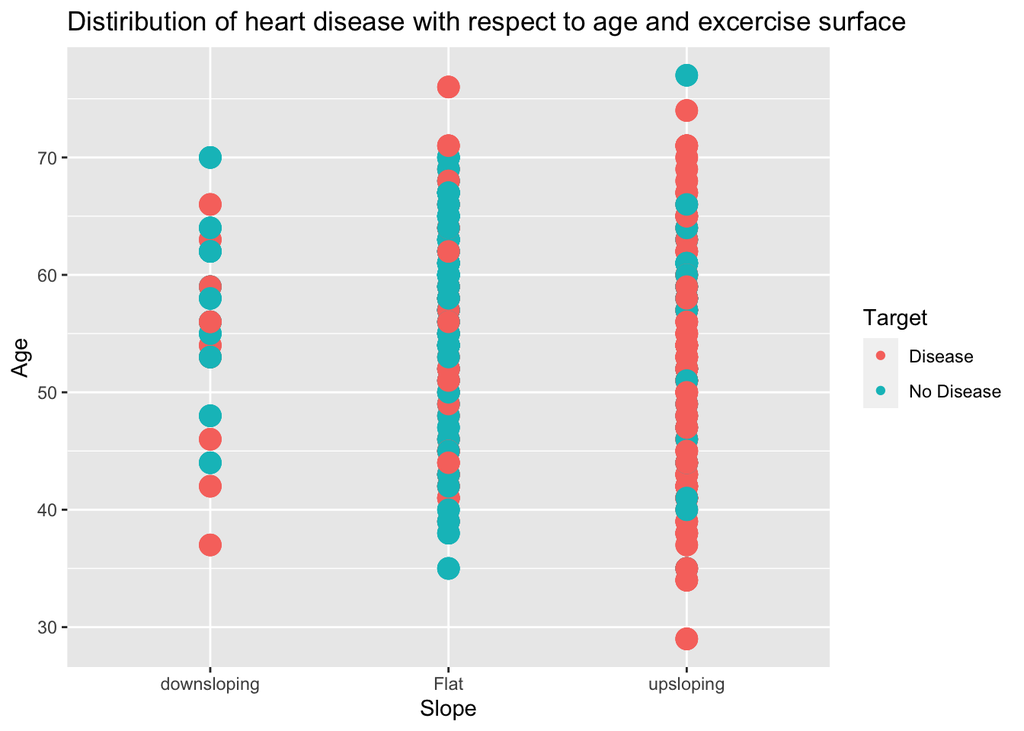

```r
df1 %>%
  ggplot()+
  geom_point(mapping = aes(x= slope, y = age, color=target, size = 10))+
  labs(x="Slope", y="Age", title="Distiribution of heart disease with respect to age and excercise surface",color = "Target") + guides(size="none")
```

#### Most people including the aged are found to exercise in flat and upsloping areas.

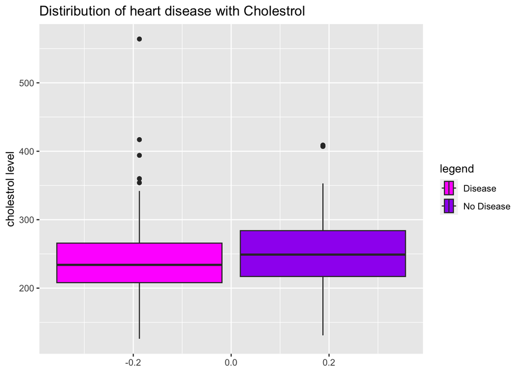

```r
df1 %>%
  ggplot() +
  geom_boxplot(mapping = aes(x = chol, fill = target))  + coord_flip() +
  scale_fill_manual("legend", values = c("Disease" = "magenta", "No Disease" = "Purple"))+labs( x= "cholestrol level", title="Distiribution of heart disease with Cholestrol")
```

#### According to the website (https://www.hopkinsmedicine.org/health/treatment-tests-and-therapies/lipid-panel), a good cholesterol level for an adult is less than 200mg/dL. According to the plot below, it starts at 200 for both persons with heart disease and those without it. There are some outliers as well. Heart disease is not primarily caused by cholesterol.

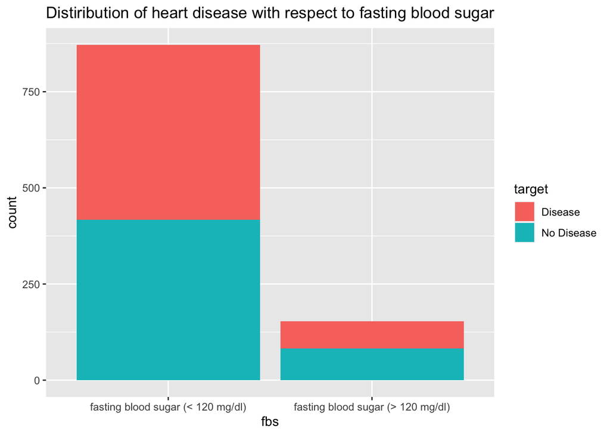

```r
df1 %>%
  ggplot()+
  geom_bar(mapping=aes(x= fbs, fill = target))+labs(title="Distiribution of heart disease with respect to fasting blood sugar")
```

#### The likelihood of developing heart disease is not affected by blood sugar levels less than or larger than 120 mg/dl. Heart disease affects persons with normal blood sugar levels as well.

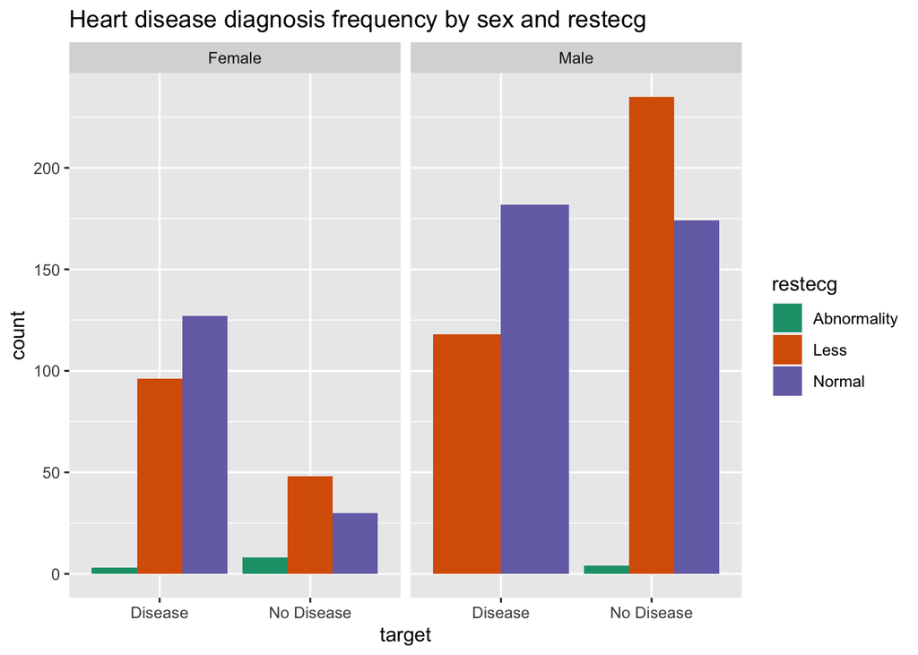

```r
df1 %>%
  ggplot()+
  geom_bar(mapping=aes(x= target, fill= restecg), position="dodge") +
  facet_grid(~sex)+
  scale_fill_brewer(palette = "Dark2")+
  labs(title = "Heart disease diagnosis frequency by sex and restecg")
```

#### Heart disease is not significantly impacted by abnormalities found in ECG readings. Since Less ECGs are normally distributed and more are normal, we can conclude that ECG frequency is not a risk factor for developing heart disease.

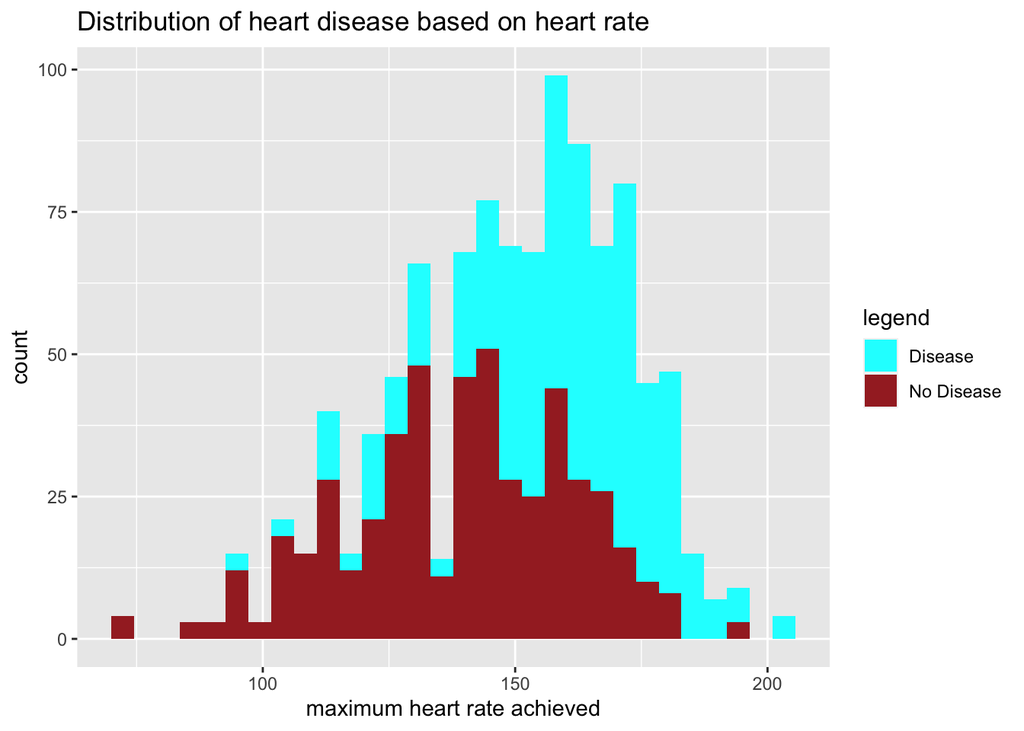

```r
df1 %>%
  ggplot()+
  #geom_point(mapping = aes(x = thalach, y = target),color = "Brown")
  geom_histogram(mapping = aes(x= thalach, fill = target), bins=30) +
  scale_fill_manual("legend", values = c("Disease" = "Cyan", "No Disease" = "brown"))+
  labs(title = "Distribution of heart disease based on heart rate", x = "maximum heart rate achieved")
```

#### Adults typically have a resting heart rate between 60 and 100 beats per minute. The healthier the person is, the lower their heart rate. As the heart rate rises, more people are prone to get heart disease, as we observe from the plot.

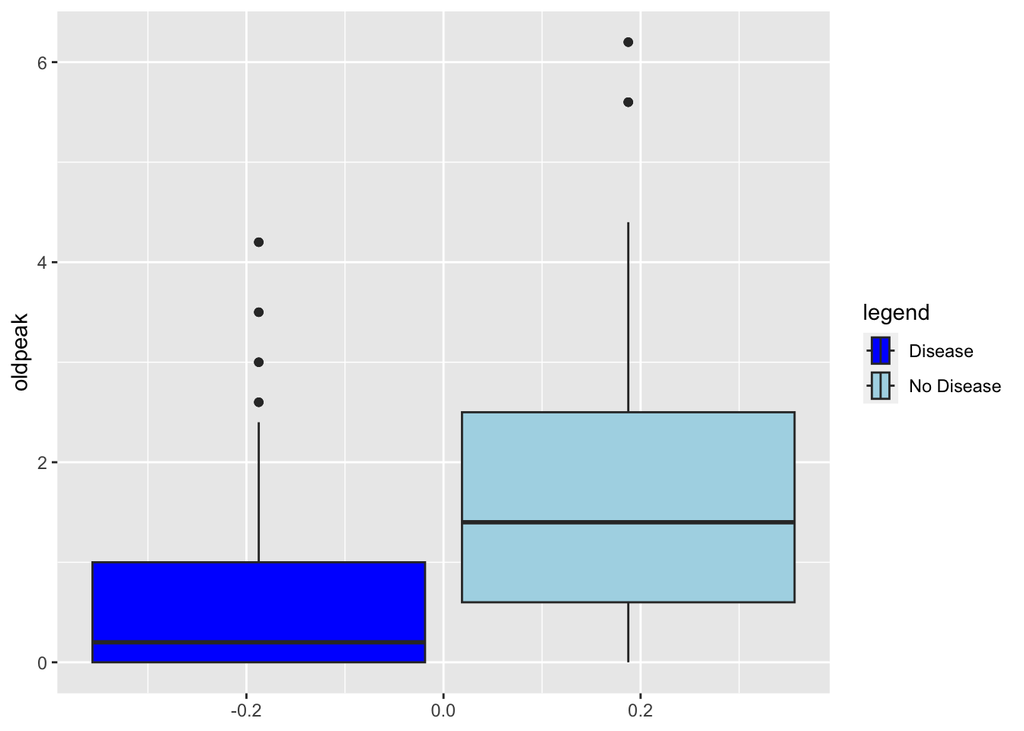

```r
df1 %>%
  ggplot() +
  geom_boxplot(mapping = aes(x = oldpeak, fill = target )) + coord_flip()+scale_fill_manual("legend", values = c("Disease" = "Blue", "No Disease" = "light blue"))
```

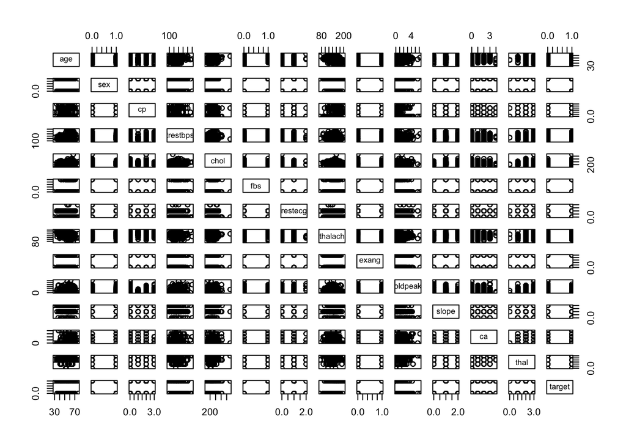

```r
pairs(df)
```

## Correlation Plot

```r
df$age <- as.numeric(df$age)
df$sex <- as.numeric(df$sex)
df$cp <- as.numeric(df$cp)
df$trestbps <- as.numeric(df$trestbps)
df$chol <- as.numeric(df$chol)
df$fbs <- as.numeric(df$fbs)
df$restecg <- as.numeric(df$restecg)
df$thalach <- as.numeric(df$thalach)
df$exang <- as.numeric(df$exang)
df$slope <- as.numeric(df$slope)
df$ca <- as.numeric(df$ca)
df$thal <- as.numeric(df$thal)
df$target <- as.numeric(df$target)
df$oldpeak <- as.numeric((df$oldpeak))
```

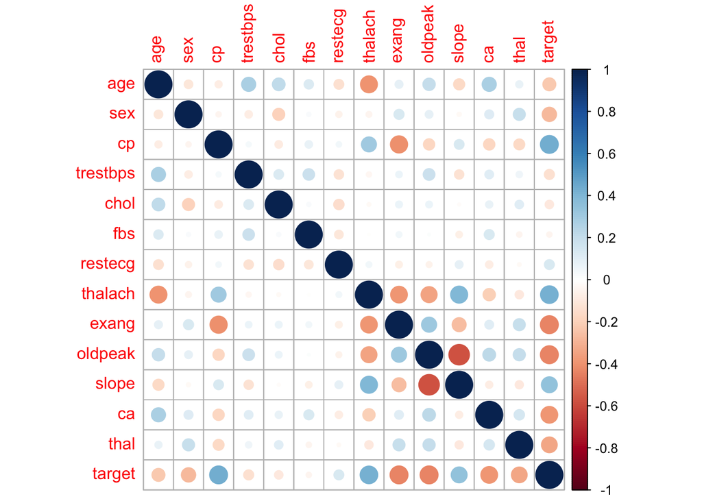

```r
#class(df$age)
corr <- cor(df[, 1:14])
corrplot(corr)
```

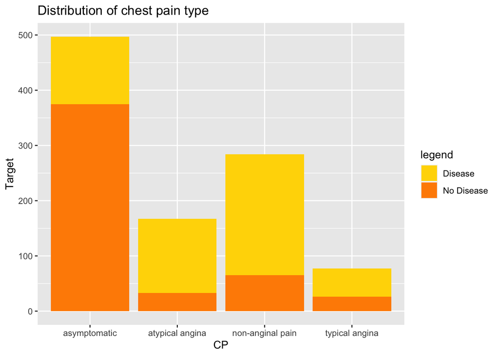

```r
g1 <- df1 %>%
  ggplot()+
  geom_bar(mapping=aes(x= cp, fill= target))+
labs(x="CP", y="Target", title="Distribution of chest pain type ")+
  scale_fill_manual("legend", values = c("Disease" = "gold", "No Disease" = "dark orange"))

g2 <- df1 %>%
  ggplot(mapping = aes(x= target, fill = cp))+
  geom_bar( position = "fill")

g1
```

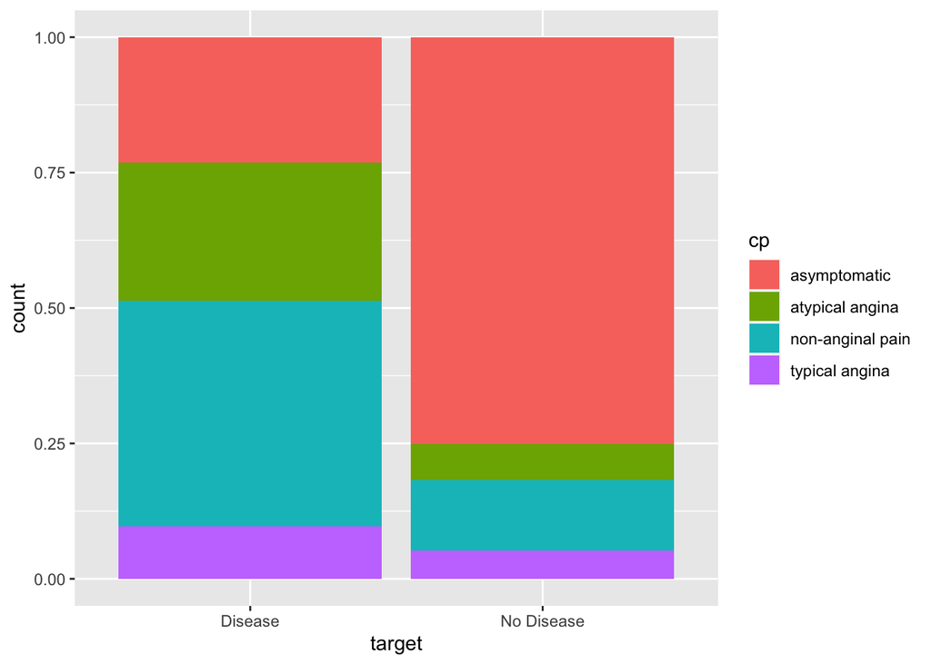

```r
g2
```